# Parameterizing the Extinction Curve

## A brief overview of data fitting

The concept of parameters comes in when trying to fit a curve to data. If we have data like the following,

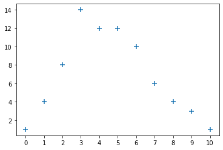

we could easily interpolate between the data points by connecting the points,

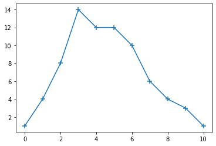

and although this curve passes through every data point, it is not very meaningful, as it has no analytic form. Usually, a model function is suggested that has a good chance of passing near most of the data points. Thus some precision is sacrificed for obtaining an analytic form for the curve. This is all right because the data are not perfectly precise anyway.

$y = a(x-b)^{-c}$+$d$

The only remaining task is to find the $a$, $b$, $c$ and $d$ values that produce the most suitable curve. This process is called fitting. The computational algorythms that carry this out vary in the details, but they all work by finding values for the parameters (here $a$, $b$, $c$ and $d$) that minimize the distance between the model curve and the data.

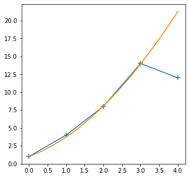

By contrived example and a little bit of fiddling, the "best-fit" parameters $a$, $b$, $c$ and $d$ were found to be 1, -1, -1.9, and 0. (in quotations because the method was eyeballing, rather than a minimization routine.)

## The extinction curve

Calculating the extinction curve is part of a broader objective in finding the observed spectral energy distribution. The SED has the following form:

> $f_\lambda = F_\lambda {\theta_R}^2 10^{-0.4E(B-V)[k(\lambda-V)+R(V)]}$

where $k(\lambda-V) \equiv E(\lambda-V)/E(B-V)$ is defined to be the unitless ratio of the colour excess at the specified wavelength to the $B-V$ colour excess. This is what the extinction curve plots as a function of wavelength (in inverse microns).

The 2007 paper by Fitzpatrick and Massa$^{\dagger}$ describes in detail how extinction curves were calculated for 328 stars. Spectrophotometric data from the International Ultraviolet Explorer satellite (IUE) were used to compute the UV portion of the extinction curve, while UBV photometry and JHK photometry from various sources including the Two-Micron All Sky Survey were used to calculate the infrared and optical regions. One of the criteria in selecting the 328 stars was that they had to have both UV and UBV data. Of these, 287 have a complete set of J-, H- and K- band measurements as well.

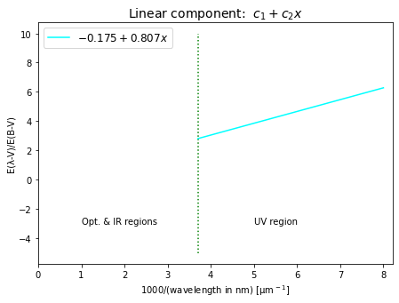

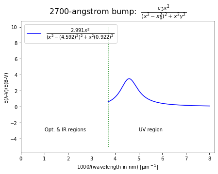

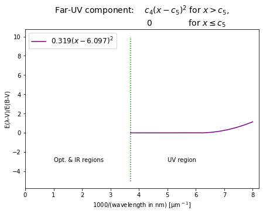

(Note that x is in inverse microns.) Adding the three pieces together results in the UV region of the extinction curve:

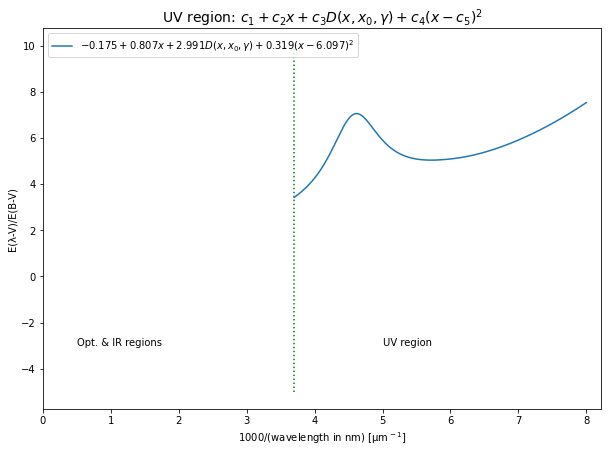

Whereas the IUE-procured data in the UV region is very complete, allowing a precise determination of the extinction curve shape, the optical and IR data consist of a set of no more than 8 datapoints obtained from photometry databases. (3 optical, 5 infrared.) Each point represents a UBV or JHK filter measurement. The curve shape is much less constrained, and the methods of achieving the curve in this region can vary. In the 2007 paper, a cubic spline is used to interpolate between the points, with the restriction that 1) the spline must smoothly connect with the UV portion, and 2) that the infrared region must follow a power law, in keeping with the known behaviour of IR extinction.

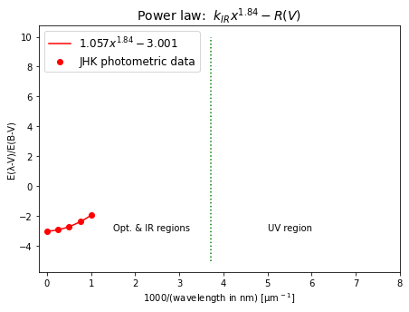

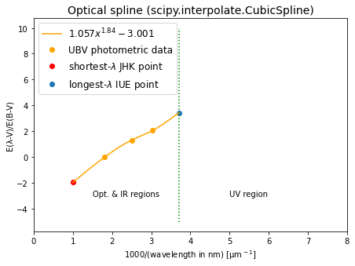

Both the spline used by this program and the spline used by the 2007 paper authors are cubic splines, although the software used to compute them may be different. If we connect the pieces of the curve, we get the final extinction curve.

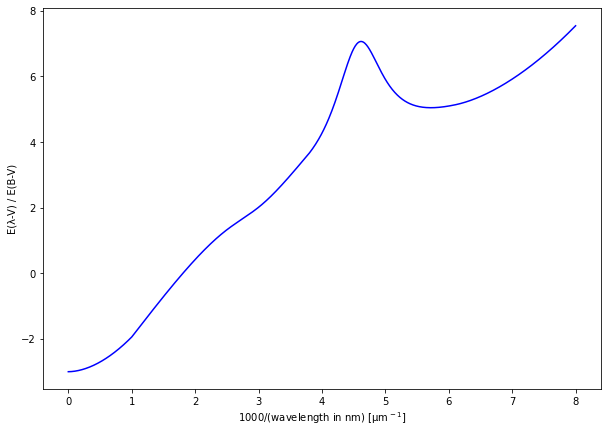

$^{\dagger}$Massa, D., & Fitzpatrick, E.L. 2007, The Astrophysics Journal, Vol. 663, p. 320